## Human Activities

#### Fishing

##### Trends: Commercial Landings

[CDFW Commerical Fishery Landings](https://wildlife.ca.gov/Fishing/Commercial/Landings)

[Leeworthy et al. 2014](https://sanctuaries.noaa.gov/science/conservation/cinms_fishing_report.html)

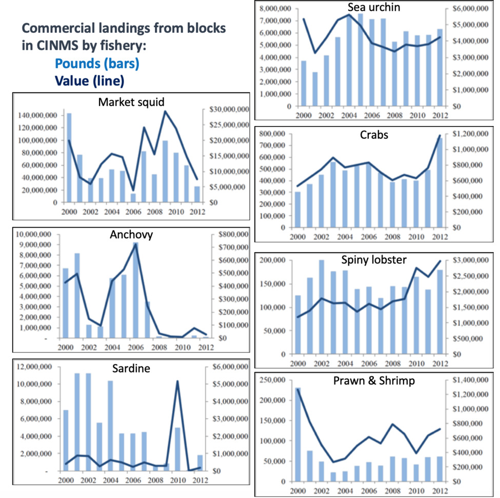

A figure showing trends in fishing catch (pounds, left y-axis) and economic value (dollars, right y-axis) for seven major fisheries around the Channel Islands (2000 to 2012). Figure credit: Leeworthy et al. 2014a.

**Click for Details**

Trends over time in commercial fishing activity in Channel Islands National Marine Sanctuary (CINMS) based on landings pounds (blue bars) and value (dark blue line) for seven fisheries from 2000 to 2012. Landings were combined for twenty-two blocks that overlap substantially with the sanctuary (see Figure App.C4.3. for map). Landings for market squid, sardine, and anchovy declined recently while landings of crabs increased. Landings of sea urchin, spiny lobster, and prawn and shrimp were relatively stable. For more information, consult Figure App.C.4.4 in the [CINMS 2016 Condition Report](https://nmssanctuaries.blob.core.windows.net/sanctuaries-prod/media/docs/2016-condition-report-channel-islands-nms.pdf).

##### Recreational

[CDFW Marine Fisheries Statistical Unit](https://wildlife.ca.gov/Conservation/Marine/MFSU)

[Data](https://caseagrant.ucsd.edu/sites/default/files/SCMPA-29-CPFV-Final-Report.pdf)

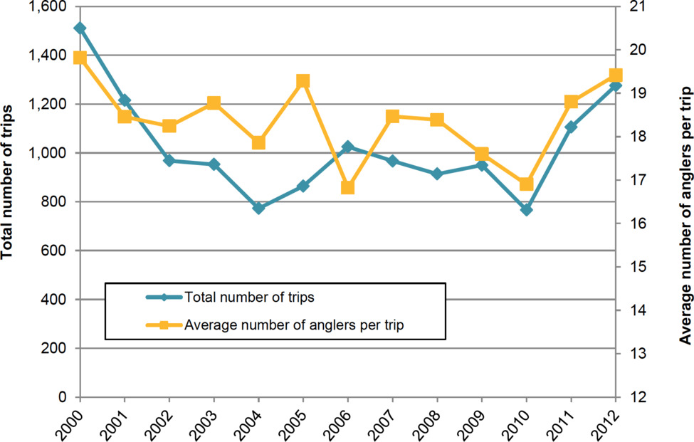

Fishing activity (number of trip and number of anglers per trip) for Commercial Passenger Fishing Vessels (CPFVs) operating out of ports in Santa Barbara and Ventura from 2000 to 2012. Figure credit: Chen et al. 2015b.

**Click for Details**

Fishing activity (number of trip and number of anglers per trip) for Commercial Passenger Fishing Vessels (CPFVs) operating out of ports in Santa Barbara and Ventura from 2000 to 2012. Figure credit: Chen et al. 2015b. For more information, consult Figure App.C.4.2a in the [CINMS 2016 Condition Report](https://nmssanctuaries.blob.core.windows.net/sanctuaries-prod/media/docs/2016-condition-report-channel-islands-nms.pdf).

[CDFW Marine Fisheries Statistical Unit](https://wildlife.ca.gov/Conservation/Marine/MFSU)

[Data](https://caseagrant.ucsd.edu/sites/default/files/SCMPA-29-CPFV-Final-Report.pdf)

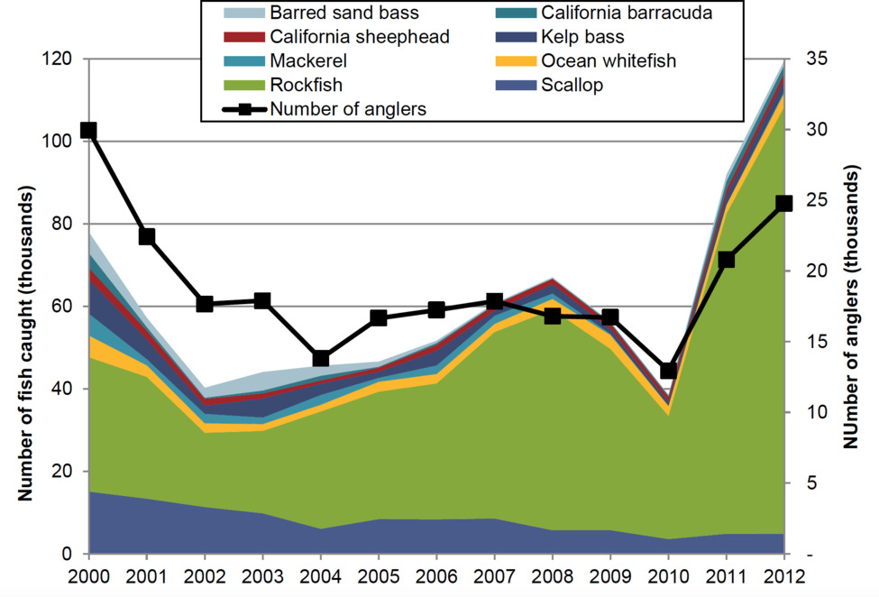

**Click for Details**

Fishing activity landings for Commercial Passenger Fishing Vessels (CPFVs) operating out of ports in Santa Barbara and Ventura from 2000 to 2012. Activity landings in 2011 and 2012 returned to levels seen in the early 2000s. For more information, consult Figure App.C.4.2b in the [CINMS 2016 Condition Report](https://nmssanctuaries.blob.core.windows.net/sanctuaries-prod/media/docs/2016-condition-report-channel-islands-nms.pdf).

#### Visitors

##### Map: Location Recreational Activity

[Data](https://caseagrant.ucsd.edu/sites/default/files/SCMPA-29-CoastalRecreation-Final-Report_0.pdf)

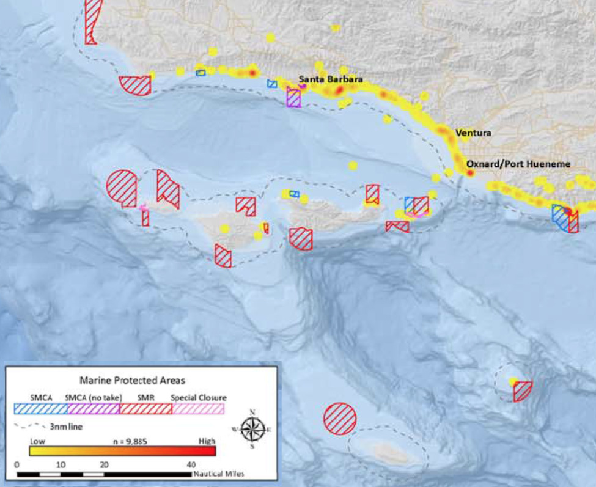

A map of the Santa Barbar Channel showing patterns in coastal recreational activity. Figure credit: Chen et al. 2015c.

**Click for Details**

Spatial patterns in coastal recreational activity levels in southern California (all activity types combined). Based on a standing internet panel designed to be demographically representative and surveyed 4,492 individuals in select south coast region counties. Activities at Channel Islands National Marine Sanctuary (CINMS) included: beach-going (SRI), scenic enjoyment (SRI, SCI, Anacapa, SBI), photography (SRI, SCI, Anacapa), birdwatching (SRI, SCI, SBI), and hiking (SRI, SCI). For more information, consult Figure App.C.4.7 in the [CINMS 2016 Condition Report](https://nmssanctuaries.blob.core.windows.net/sanctuaries-prod/media/docs/2016-condition-report-channel-islands-nms.pdf).

##### Trends: Visitors (CHIS)

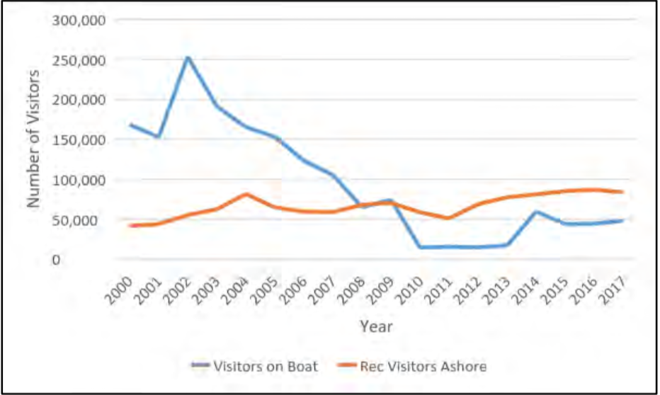

#### Research

##### Trends: Active Permits

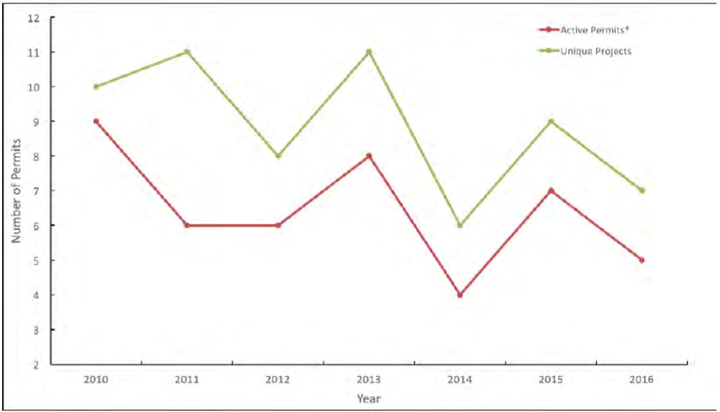

Annual number of unique research projects (green) and active research permits (red) in the California Department of Fish and Wildlife (CDFW) database for research permits in Channel Islands National Marine Sanctuary (CINMS) from 2010 to 2016. One permit could contain multiple projects. Data source: B. Owens/ CDFW; Figure credit: NOAA.

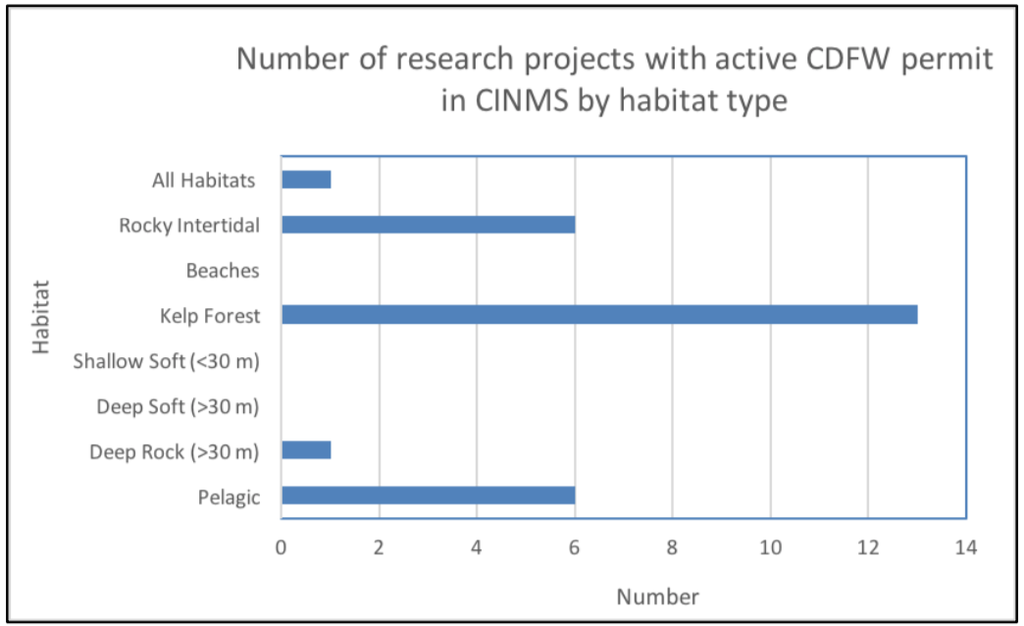

Number of projects with active CDFW research permits in CINMS by habitat type. Active permits only include those that are currently in use; non-student permits are issued for three years and student permits are issued for only one year. Student permits issued before June 6, 2015 were not included in this summary.

## Human Impacts

#### Noise

###### Listening Stations

[Monitoring Program](https://sanctuarysimon.org/dbtools/project-database/index.php?ID=100506)

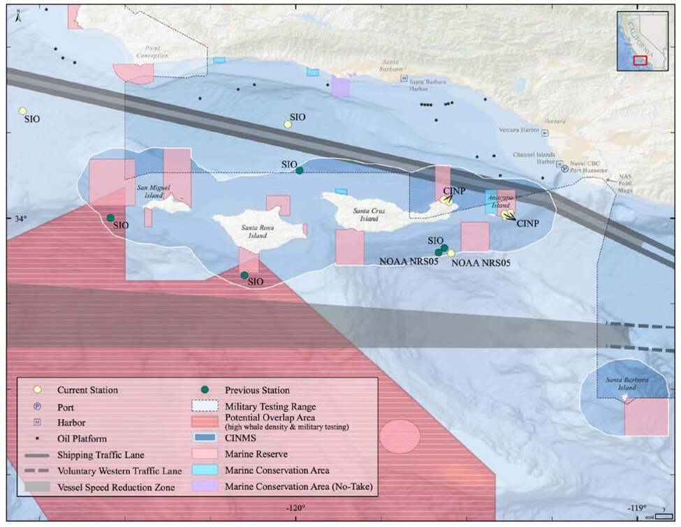

A map showing the location of historic (green dots) and current (yellow dots) passive acoustic monitoring stations around the Sanctuary and Santa Barbara Channel. Map credit: [M. Cajandig/NOAA](https://channelislands.noaa.gov/contact/cajandig.html).

**Click for Details**

Previous (green dots) and current (yellow dots) passive acoustic monitoring stations in and around CINMS are shown along with several sources of anthropogenic noise: ports and harbors, oil platforms, shipping lanes, and military testing zones. SIO = Scripps Institution of Oceanography; NOAA NRS = Noise Reference Station. For more information, consult Figure App.C.2.8 in the [CINMS 2016 Condition Report](https://nmssanctuaries.blob.core.windows.net/sanctuaries-prod/media/docs/2016-condition-report-channel-islands-nms.pdf).

###### Trends: Sound Levels

[Shipping Noise Monitoring](https://sanctuarysimon.org/dbtools/project-database/index.php?ID=100426)

[McKenna et al. 2012](http://dx.doi.org/10.1121/1.4740225)

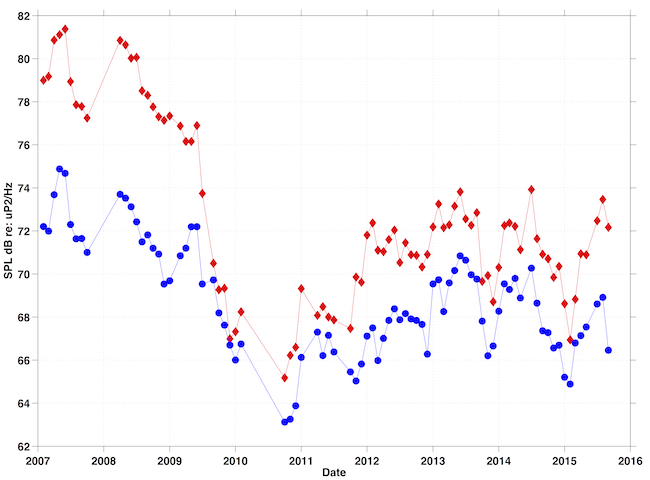

A graph showing noise levels in the Santa Barbara Channel from 2007 to 2016. 40Hz bands are shown in red, 90Hz bands are shown in blue. Data sources: McKenna et al. 2012, J. Hildebrand/ UCSD unpub. data; Figure credit: [J. Hildebrand/SIO UCSD](http://cetus.ucsd.edu/profile_JohnHildebrand.html).

**Click for Details**

Ambient noise levels in the Santa Barbara Channel represented as monthly averages for 40 Hz (red) and 90 Hz (blue) bands. The decline in ambient noise levels observed between 2007 and 2010 reflects decreased regional shipping activity during that time. While ambient noise has increased since 2010, it has not returned to the higher levels observed in 2007 to 2008. For more information, consult Figure App.C.4.13 in the [CINMS 2016 Condition Report](https://nmssanctuaries.blob.core.windows.net/sanctuaries-prod/media/docs/2016-condition-report-channel-islands-nms.pdf).